# a3q2v2

#### Description and Context of population:

The data set is of Billboard Top 30 songs from 2010 to 2019. The following data has different variates of every song in the Billboard Top 30 for the years 2010 to 2019.

```r
spotify <- read.csv("./spotify.csv", header=TRUE)
Spotify = na.omit(spotify)
data <- Spotify[Spotify$popularity > 0,]
data <- Spotify[Spotify$duration > 0,]
```

```r
ratio.variable = data$popularity / data$duration
```

Calculating $\alpha$ which makes the skewness equal to 0.

```r
ratio.variable = ratio.variable[ratio.variable < 1]
ratioSkew = createSkewFunction( ratio.variable )
ratio.alpha= uniroot(ratioSkew, interval=c(-1,1))$root;
ratio.alpha
```

```
## [1] 0.3349566
```

Generating transformed variable

```r
trans.ratio = powerfun(ratio.variable, ratio.alpha)
```

Standardizing the variable i.e performing a location and scale shift

```r
st.ratio = (trans.ratio - mean(trans.ratio))/sdn(trans.ratio)
```

Verifying the mean, standard deviation and skewness

```r
c(mean(st.ratio), sd(st.ratio), skew(st.ratio))
```

```
## [1] -7.900704e-16  1.001671e+00 -4.516119e-06
```

Plotting the histogram of the transformed and standardized variable

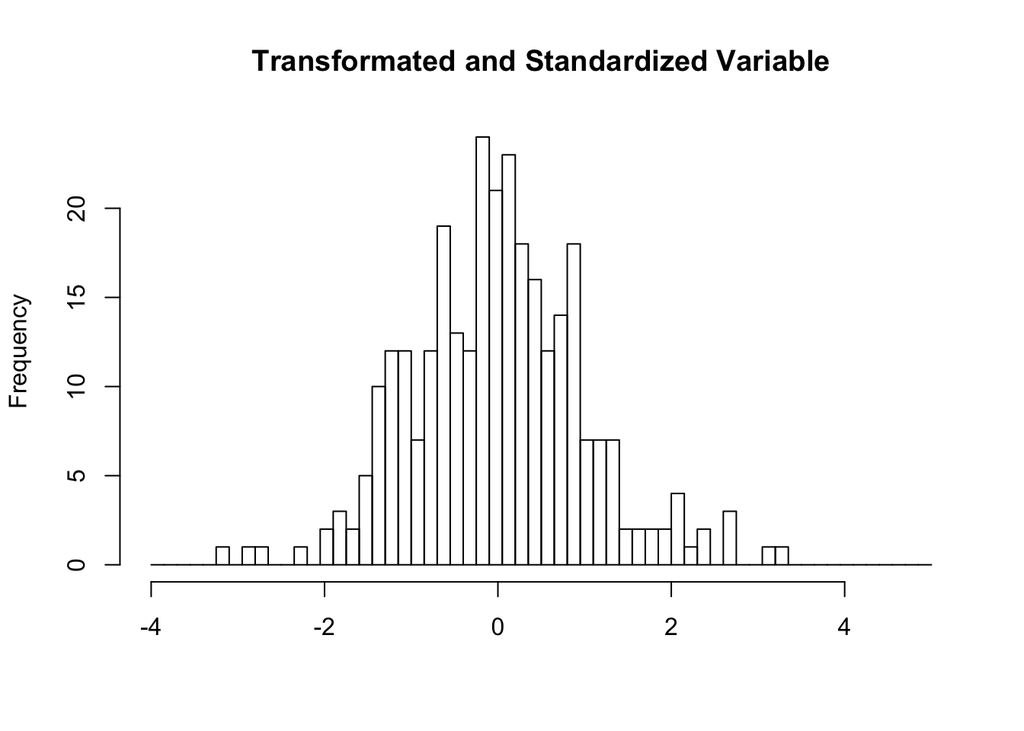

```r
hist( st.ratio, breaks=seq(-4, 5, 0.15), main="Transformated and Standardized Variable", xlab="")
```

```r
sim.avg.mean <- function(pop=NULL, n=NULL, m=10^4) {
N = length(pop);
set.seed(341)
temp = unlist(Map(function(rep) {
  sam.values = pop[sample(N, n, replace=FALSE)]
  c(mean(sam.values), median(sam.values))}, 1:m))
  temp = matrix( temp, nrow=m, ncol=2, byrow=TRUE)
  temp = c(apply(temp, 2, mean)- c(mean(pop) , median(pop)) , apply(temp, 2, sd) )
  result=c(temp,temp[1]^2+temp[3]^2,temp[2]^2+temp[4]^2)
  return(result)
}
```

#### Numerical Comparision

We will now find * Average Standard Bias and Meadian Standard Bias * Average Standard Deviation and Median Standard Deviation * Average Mean Squared Error and Median Mean Squared Error

```r
n.set = seq(30,300, by=30)
result = matrix(nrow=length(n.set), ncol=6,
dimnames = list(n.set, c("Avg. SB", "Median SB", "Avg. SD", "Median SD", "Avg. MSE","Median MSE" )))
for (i in 1:length(n.set)){
  result[i,] = sim.avg.mean(st.ratio, n=n.set[i])
}
round(result,4)
```

```
##     Avg. SB Median SB Avg. SD Median SD Avg. MSE Median MSE
## 30   0.0002   -0.0093  0.1725    0.1800   0.0298     0.0325
## 60  -0.0011   -0.0041  0.1166    0.1171   0.0136     0.0137
## 90  -0.0004   -0.0014  0.0883    0.0902   0.0078     0.0081
## 120 -0.0002   -0.0003  0.0707    0.0730   0.0050     0.0053
## 150  0.0001    0.0025  0.0577    0.0606   0.0033     0.0037
## 180  0.0000    0.0036  0.0470    0.0496   0.0022     0.0025
## 210 -0.0002    0.0046  0.0380    0.0401   0.0014     0.0016
## 240  0.0000    0.0049  0.0290    0.0308   0.0008     0.0010
## 270  0.0000    0.0042  0.0190    0.0222   0.0004     0.0005
## 300  0.0000    0.0000  0.0000    0.0000   0.0000     0.0000
```

- SB denotes the estimate of the sampling bias and SD denotes the estimate of the sampling standard deviation. The last two columons show the MSE calculated from the sample.
- The Average performs better then the median in this situation as its MSE is consistently smaller than that of the median

#### Graphical Comparision

We will now look at the above estimators graphically. The black line will correspond to the average estimator and the blue line corresponds to the median estimator.

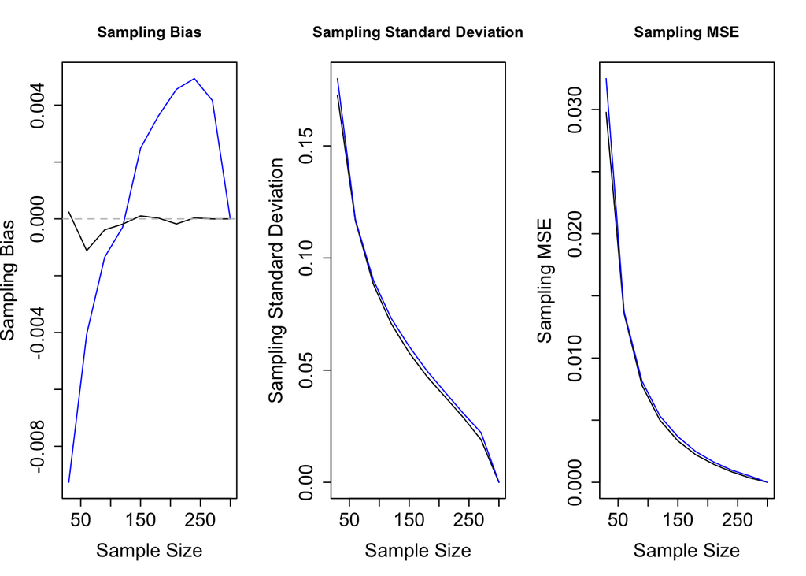

```r
par(mfrow=c(1,3),oma=c(0,0,0,0))

plot( result[,1]~n.set, main="Sampling Bias", type='l', ylim=range(result[,1:2]), ylab="Sampling Bias", xlab="Sample Size" ,cex.lab=1.5 , cex.axis=1.5)
lines( result[,2]~n.set, col=4)
abline(h=0, lty=2, col="grey")

plot(result[,3]~n.set, main="Sampling Standard Deviation", type='l', ylim=c(0,max(result[,3:4])), xlab="Sample Size", ylab="Sampling Standard Deviation",cex.lab=1.5 , cex.axis=1.5)
lines( result[,4]~n.set, col=4)

plot( result[,5]~n.set, main="Sampling MSE", type='l',
ylim=c(0,max(result[,5:6]) ), xlab="Sample Size", ylab="Sampling MSE",
cex.lab=1.5 , cex.axis=1.5)
lines( result[,6]~n.set, col=4)
```